# Housing Data Analysis

Checking for relationship between numeric and categorical variables

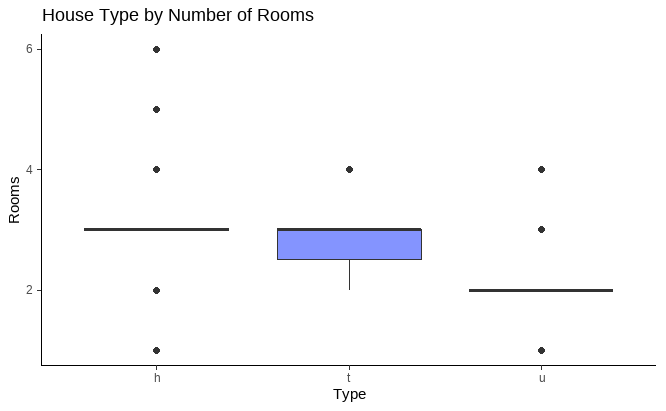

```r
ggplot(houses, aes(x=Type, y=Rooms)) +
  geom_boxplot(fill="#8494FF") +
  theme_classic() +
  labs(title="House Type by Number of Rooms")
```

On average, type “u” houses have smaller amount of rooms, comparing to other properties.

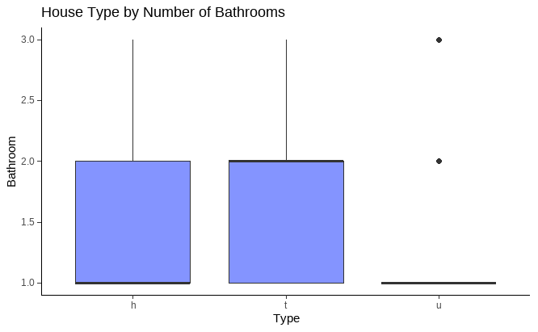

```r
ggplot(houses, aes(x=Type, y=Bathroom)) +
  geom_boxplot(fill="#8494FF") +
  theme_classic() +
  labs(title="House Type by Number of Bathrooms")
```

On the box plot above we can notice some similarities regarding the number of bathrooms in townhouses and common houses.

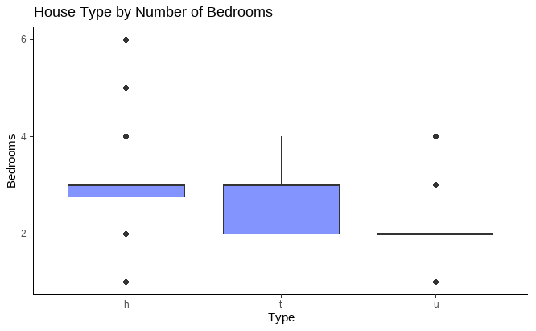

```r
ggplot(houses, aes(x=Type, y=Bedrooms)) +
  geom_boxplot(fill="#8494FF") +
  theme_classic() +
  labs(title="House Type by Number of Bedrooms")
```

Unit and duplex houses have smaller amount of bedrooms, comparing to the other properties.

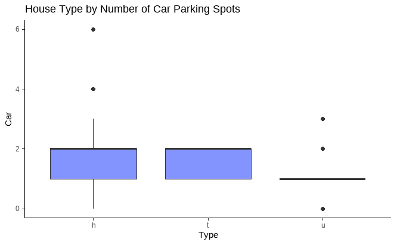

```r
ggplot(houses, aes(x=Type, y=Car)) +
  geom_boxplot(fill="#8494FF") +
  theme_classic() +
  labs(title="House Type by Number of Car Parking Spots")
```

There does not seem to be any significant relationship between those variables.

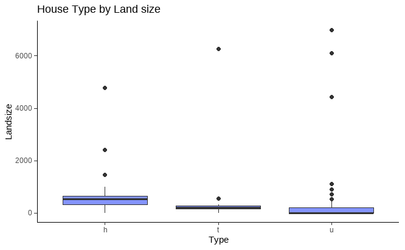

```r
ggplot(houses, aes(x=Type, y=Landsize)) +
  geom_boxplot(fill="#8494FF") +
  theme_classic() +
  labs(title="House Type by Land size")
```

What could be noticed above is that the type “h” properties tend to have more land size than any other property.

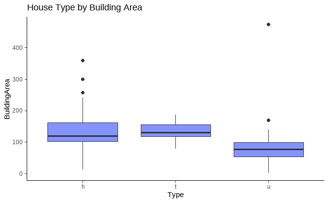

```r
ggplot(houses, aes(x=Type, y=BuildingArea)) +
  geom_boxplot(fill="#8494FF") +
  theme_classic() +
  labs(title="House Type by Building Area")
```

There does not seem to be any relevant relationship, it can only be seen that the unit and duplex houses tend to be smaller, which were to be expected.

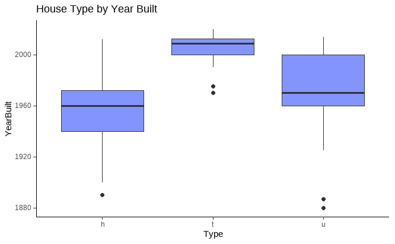

```r
ggplot(houses, aes(x=Type, y=YearBuilt)) +
  geom_boxplot(fill="#8494FF") +
  theme_classic() +
  labs(title="House Type by Year Built")
```

Townhouses tend to be built later than other types of houses, which could indicate some architecture trends, although regarding our research question it does not seem to provide the analysis with some useful insights.

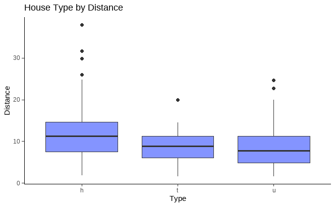

```r
ggplot(houses, aes(x=Type, y=Distance)) +
  geom_boxplot(fill="#8494FF") +
  theme_classic() +
  labs(title="House Type by Distance")
```

There does not seem to be any relevant relationship between *Type* and *Distance*

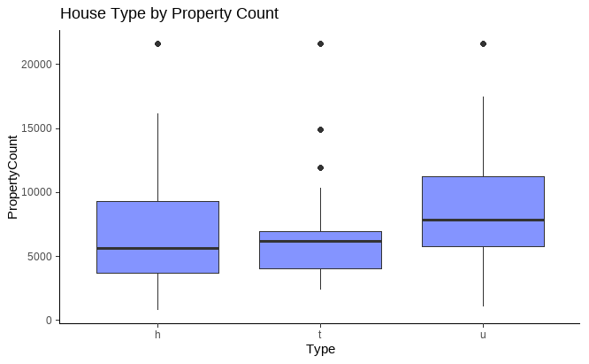

```r
ggplot(houses, aes(x=Type, y=PropertyCount)) +
  geom_boxplot(fill="#8494FF") +
  theme_classic() +
  labs(title="House Type by Property Count")
```

What is interesting on the box plot is that unit and duplex houses have higher *PropertyCount* values, but it does not seem to be significant in the analysis.

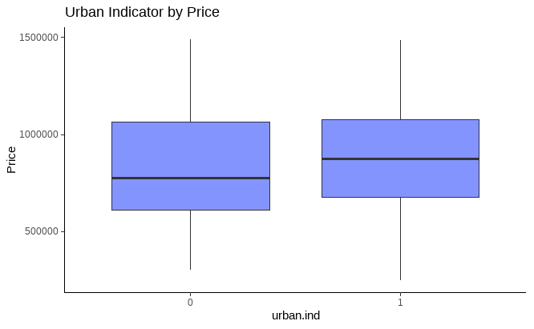

```r
ggplot(houses, aes(x=urban.ind, y=Price)) +
  geom_boxplot(fill="#8494FF") +
  theme_classic() +
  labs(title="Urban Indicator by Price")
```

As we can see on this box plot, the properties that have shorter distance to the Commercial Business District have higher prices. This is a relationship that could be investigated further in the next stages.

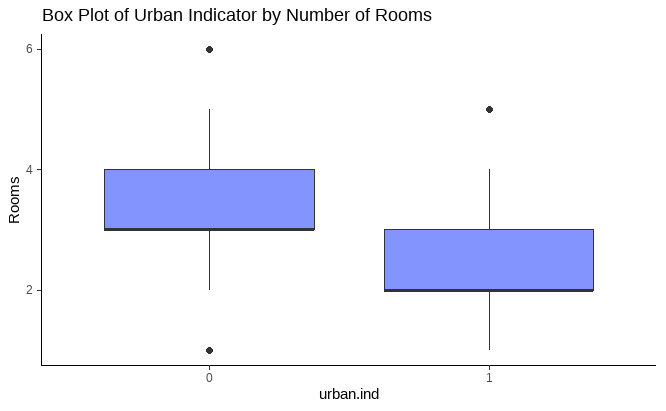

```r
ggplot(houses, aes(x=urban.ind, y=Rooms)) +
  geom_boxplot(fill="#8494FF") +
  theme_classic() +
  labs(title="Box Plot of Urban Indicator by Number of Rooms")
```

Properties that are further away from the Commercial Business District tend to have more rooms, which could be an interesting feature to investigate.

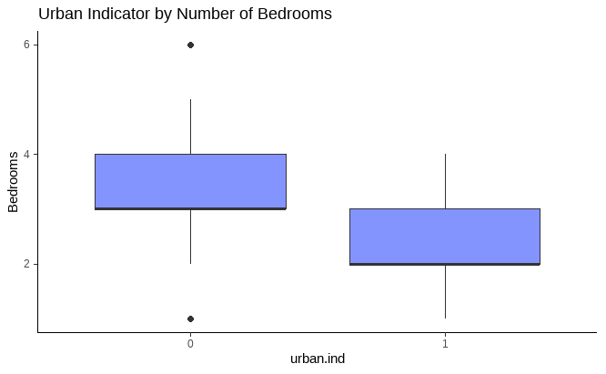

```r
ggplot(houses, aes(x=urban.ind, y=Bedrooms)) +
  geom_boxplot(fill="#8494FF") +
  theme_classic() +
  labs(title="Urban Indicator by Number of Bedrooms")
```

It is possible that properties usually have more bedrooms when being further away from the business district.

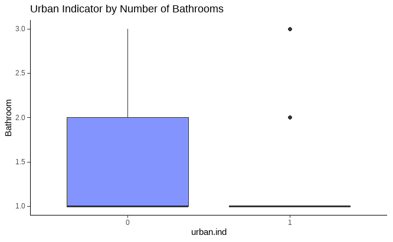

```r
ggplot(houses, aes(x=urban.ind, y=Bathroom)) +
  geom_boxplot(fill="#8494FF") +
  theme_classic() +
  labs(title="Urban Indicator by Number of Bathrooms")
```

It could be that the properties not within 10 miles of the CBD usually have larger amount of bathrooms, although this relationship should be investigated in more detail.

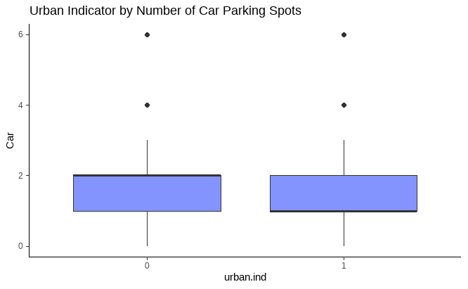

```r
ggplot(houses, aes(x=urban.ind, y=Car)) +
  geom_boxplot(fill="#8494FF") +
  theme_classic() +
  labs(title="Urban Indicator by Number of Car Parking Spots")
```

There does not seem to be any connection between being in the vicinity of the business district and number of parking spots.

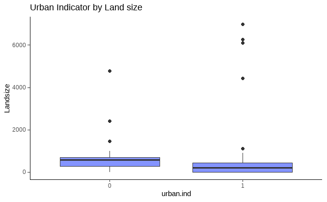

```r
ggplot(houses, aes(x=urban.ind, y=Landsize)) +
  geom_boxplot(fill="#8494FF") +
  theme_classic() +
  labs(title="Urban Indicator by Land size")
```

We can conclude from the plot above that the properties which are not in the vicinity of Commercial Business District tend to have larger land size.

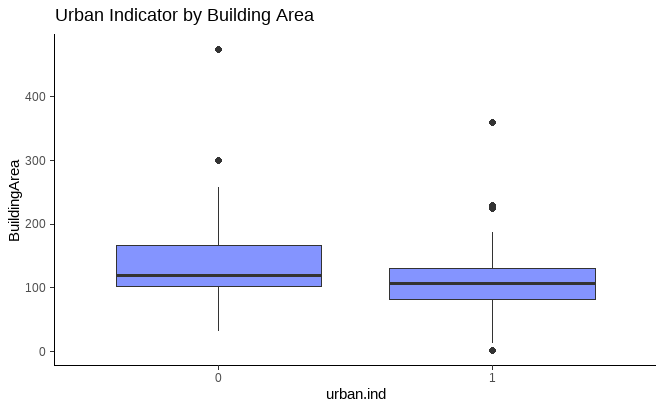

```r
ggplot(houses, aes(x=urban.ind, y=BuildingArea)) +
  geom_boxplot(fill="#8494FF") +
  theme_classic() +
  labs(title="Urban Indicator by Building Area")
```

Similarly to *Landsize*, properties that are not within 10 miles of the CBD usually have bigger building size.

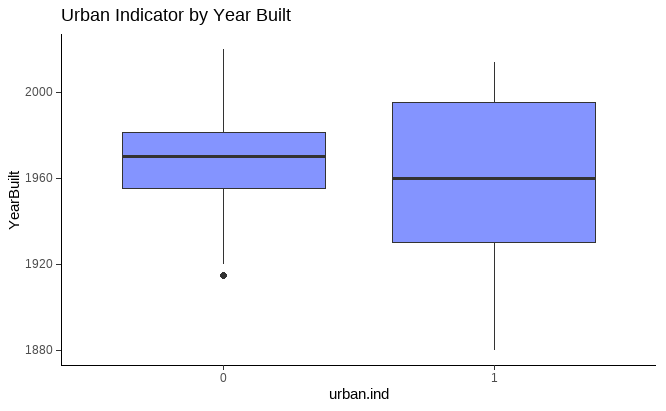

```r
ggplot(houses, aes(x=urban.ind, y=YearBuilt)) +
  geom_boxplot(fill="#8494FF") +
  theme_classic() +
  labs(title="Urban Indicator by Year Built")
```

In this case, the relationship between *urban.ind* and *YearBuilt* is not clear. Overall more properties that were built sooner are in the vicinity of CBD, although on average the houses that are further away are “younger”.

After analysing the continuous variables I have moved to analysing categorical variables. Since *ID* is just an identifier, it has been omitted in the analysis.

First, I have plotted a frequency table for the factor *Type*.

```r
table(houses$Type)
```

```
  h   t   u
200  23  71
```

We can see that the majority of properties are houses (cottage, villas, semi-detached, terrace); second largest group are unit and duplex houses. For better visualisation, bar chart has been plotted below.

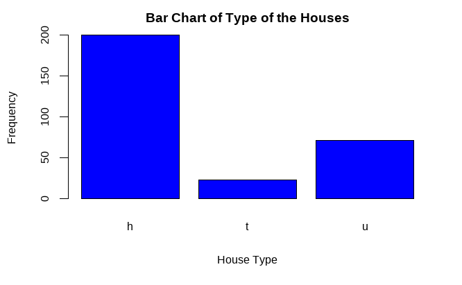

```r
barplot(table(houses$Type), xlab = "House Type", ylab = "Frequency", main="Bar Chart of Type of the Houses", col = "blue")
```

Next categorical variable is *urban.ind*.

```r
table(houses$urban.ind)
```

```
  0   1
149 145
```

The values seem to be nearly equally divided in the data set, there is only 4 less houses within 10 miles of the Commercial Business District.

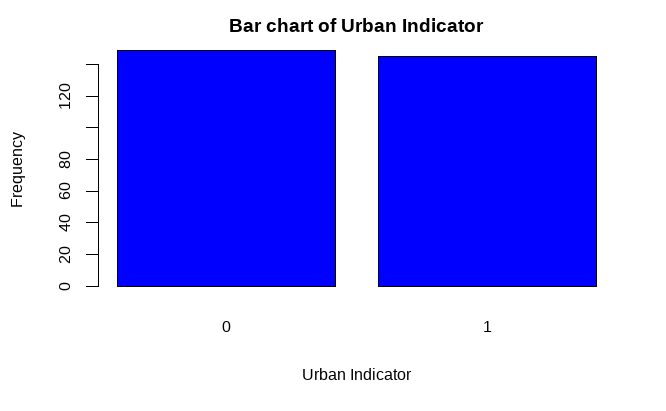

```r
barplot(table(houses$urban.ind), xlab = "Urban Indicator", ylab = "Frequency", main = "Bar chart of Urban Indicator", col = "blue")
```

In the next step, multivariate analysis has been performed. For that purpose I have created a subset of the data that contains only continuous variables.

```r
houses_num <- subset(houses, select = c(Price, Rooms, Bedrooms, Bathroom, Car, Landsize, BuildingArea, YearBuilt, Distance, PropertyCount))

# Getting the structure of the newly created subset
str(houses_num)
```

```
'data.frame':   294 obs. of  10 variables:
 $ Price        : num  1030000 978000 1120000 781000 678000 940000 1050000 968000 851000 790000 ...
 $ Rooms        : int  2 4 3 3 2 2 3 3 3 4 ...
 $ Bedrooms     : int  2 4 3 3 2 2 3 3 3 4 ...
 $ Bathroom     : num  1 3 1 1 1 1 2 1 3 2 ...
 $ Car          : int  1 2 2 2 2 1 2 1 1 2 ...
 $ Landsize     : num  172 532 506 533 0 330 318 227 557 570 ...
 $ BuildingArea : num  81 NA 120 117 NA NA 160 NA 181 NA ...
 $ YearBuilt    : num  1930 NA 1930 1970 NA ...
 $ Distance     : num  2.5 13.5 13.8 11.1 6.3 5.9 5.9 11 10.5 10.5 ...
 $ PropertyCount: int  4019 3464 5301 5132 4836 6567 6567 3052 4502 4502 ...
```

Next, I have used correlate() function in order to compute Pearson coefficient for the variables.

```r
correlate(houses_num, Price)
```

| var1 | var2 | coef_corr |
| --- | --- | --- |
| Price | Rooms | 0.41773501 |
| Price | Bedrooms | 0.40183051 |
| Price | Bathroom | 0.23573155 |
| Price | Car | 0.19129218 |
| Price | Landsize | 0.17673376 |
| Price | BuildingArea | 0.33429881 |
| Price | YearBuilt | -0.34513453 |
| Price | Distance | -0.14736177 |
| Price | PropertyCount | -0.03794076 |

Given that the correlation coefficient of +0.3/-0.3 represents a moderate correlation and values of +0.5/-0.5 represent strong or large correlation, the variables that are considered to be significantly correlated with *Price* are: *Rooms*, *Bedrooms*, *BuildingArea* and *YearBuilt*.

In the next step, I have checked the variables for multi-colinearity:

```r
cor(houses_num)
```

```
                    Price       Rooms    Bedrooms   Bathroom
Price          1.00000000  0.41773501 0.401830513 0.23573155
Rooms          0.41773501  1.00000000 0.950707634 0.58097889
Bedrooms       0.40183051  0.95070763 1.000000000 0.54502843
Bathroom       0.23573155  0.58097889 0.545028427 1.00000000
Car            0.19129218  0.36404365 0.357368185 0.26909322
Landsize       0.17673376  0.15088814 0.149907956 0.18277636
BuildingArea           NA          NA          NA         NA
YearBuilt              NA          NA          NA         NA
Distance      -0.14736177  0.36372656 0.382085561 0.25275725
PropertyCount -0.03794076 -0.03214561 0.008520436 0.01534227
                     Car   Landsize BuildingArea YearBuilt
Price         0.19129218 0.17673376           NA        NA
Rooms         0.36404365 0.15088814           NA        NA
Bedrooms      0.35736819 0.14990796           NA        NA
Bathroom      0.26909322 0.18277636           NA        NA
Car           1.00000000 0.23696810           NA        NA
Landsize      0.23696810 1.00000000           NA        NA
BuildingArea          NA         NA            1        NA
YearBuilt             NA         NA           NA         1
Distance      0.25270799 0.16428857           NA        NA
PropertyCount 0.01633206 0.01268181           NA        NA
                 Distance PropertyCount
Price         -0.14736177  -0.037940758
Rooms          0.36372656  -0.032145615
Bedrooms       0.38208556   0.008520436
Bathroom       0.25275725   0.015342267
Car            0.25270799   0.016332057
Landsize       0.16428857   0.012681814
BuildingArea           NA            NA
YearBuilt              NA            NA
Distance       1.00000000  -0.021733653
PropertyCount -0.02173365   1.000000000
```

## 2.3 Additional insights and issues

As we could see, the data is not normally distributed, 9 out of 10 continuous variables have positive skewness. This could suggest undertaking some additional steps, like transformating the data (i.e. sqrt or log transformations). Also, it is worth mentioning that *BuildingArea* and *YearBuilt* have plenty of missing values, what could influence the analysis in a negative way. Eventually, it could be beneficial to build a model on both incomplete and imputated or trimmed data and compare the results.

# 3. Modelling

## 3.1 Build a model for property price

Before building the model, the data has been investigated in terms of outliers and missing values. All necessary data cleaning operations have been performed, thus I have moved on to build a model for property price.

First, I have plotted a regression tree in order to initially check which variables affect *Price* the most.

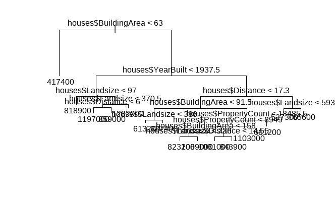

```r
houses.tree <- tree(houses$Price ~ houses$Bedrooms + houses$Bathroom + houses$Car + houses$Landsize + houses$BuildingArea + houses$YearBuilt + houses$Distance + houses$PropertyCount + houses$urban.ind, data = houses)

plot(houses.tree)
text(houses.tree)
```

From the regression tree I have noticed that *BuildingArea* is the most important factor, being the root node. *YearBuilt* seems to be the second most influential factor. There is also large amount of branches in the tree, what could indicate that the model initially could have good level of complexity.

In the next step, I have built a maximal model for evaluating price by using all explanatory variables.

```r
houses_max_model.lm <- lm(houses$Price ~ houses$Bedrooms + houses$Bathroom + houses$Car + houses$Landsize + houses$BuildingArea + houses$YearBuilt + houses$Distance + houses$PropertyCount + houses$urban.ind, data = houses)

houses_max_model.lm
```

```
Call:
lm(formula = houses$Price ~ houses$Bedrooms + houses$Bathroom +
    houses$Car + houses$Landsize + houses$BuildingArea + houses$YearBuilt +
    houses$Distance + houses$PropertyCount + houses$urban.ind,
    data = houses)

Coefficients:
         (Intercept)       houses$Bedrooms
           8.141e+06             7.139e+04
     houses$Bathroom            houses$Car
           6.797e+04             3.948e+04
     houses$Landsize   houses$BuildingArea
           7.046e+01             1.210e+03
    houses$YearBuilt       houses$Distance
          -3.875e+03            -1.516e+04
houses$PropertyCount     houses$urban.ind1
          -4.495e+00            -1.979e+04
```

```r
summary.lm(houses_max_model.lm)
```

```
Call:
lm(formula = houses$Price ~ houses$Bedrooms + houses$Bathroom +
    houses$Car + houses$Landsize + houses$BuildingArea + houses$YearBuilt +
    houses$Distance + houses$PropertyCount + houses$urban.ind,
    data = houses)

Residuals:
    Min      1Q  Median      3Q     Max
-540057 -166845  -45464  154714  586792

Coefficients:
                       Estimate Std. Error t value Pr(>|t|)
(Intercept)           8.141e+06  1.263e+06   6.444 1.41e-09
houses$Bedrooms       7.139e+04  3.086e+04   2.313  0.02204
houses$Bathroom       6.797e+04  4.703e+04   1.445  0.15042
houses$Car            3.948e+04  2.086e+04   1.892  0.06033
houses$Landsize       7.046e+01  2.311e+01   3.048  0.00271
houses$BuildingArea   1.210e+03  4.216e+02   2.870  0.00468
houses$YearBuilt     -3.875e+03  6.476e+02  -5.984 1.47e-08
houses$Distance      -1.516e+04  4.704e+03  -3.224  0.00155
houses$PropertyCount -4.495e+00  3.589e+00  -1.252  0.21233
houses$urban.ind1    -1.979e+04  5.487e+04  -0.361  0.71887

(Intercept)          ***
houses$Bedrooms      *
houses$Bathroom
houses$Car           .
houses$Landsize      **
houses$BuildingArea  **
houses$YearBuilt     ***
houses$Distance      **
houses$PropertyCount
houses$urban.ind1
---
Signif. codes:  0 ‘***’ 0.001 ‘**’ 0.01 ‘*’ 0.05 ‘.’ 0.1 ‘ ’ 1

Residual standard error: 233200 on 154 degrees of freedom
  (130 observations deleted due to missingness)
Multiple R-squared:  0.4336,    Adjusted R-squared:  0.4005
F-statistic:  13.1 on 9 and 154 DF,  p-value: 2.128e-15
```

Next, I have built a simplified, minimal adequate model:

```r
houses_min_model.lm <- step(houses_max_model.lm)
```

```
Start:  AIC=4063.65
houses$Price ~ houses$Bedrooms + houses$Bathroom + houses$Car +
    houses$Landsize + houses$BuildingArea + houses$YearBuilt +
    houses$Distance + houses$PropertyCount + houses$urban.ind

                       Df  Sum of Sq        RSS    AIC
- houses$urban.ind      1 7.0727e+09 8.3820e+12 4061.8
- houses$PropertyCount  1 8.5298e+10 8.4602e+12 4063.3
<none>                               8.3749e+12 4063.6
- houses$Bathroom       1 1.1359e+11 8.4885e+12 4063.9
- houses$Car            1 1.9474e+11 8.5696e+12 4065.4
- houses$Bedrooms       1 2.9098e+11 8.6659e+12 4067.2
- houses$BuildingArea   1 4.4797e+11 8.8228e+12 4070.2
- houses$Landsize       1 5.0533e+11 8.8802e+12 4071.3
- houses$Distance       1 5.6511e+11 8.9400e+12 4072.4
- houses$YearBuilt      1 1.9476e+12 1.0323e+13 4095.9

Step:  AIC=4061.79
houses$Price ~ houses$Bedrooms + houses$Bathroom + houses$Car +
    houses$Landsize + houses$BuildingArea + houses$YearBuilt +
    houses$Distance + houses$PropertyCount

                       Df  Sum of Sq        RSS    AIC
- houses$PropertyCount  1 8.2566e+10 8.4645e+12 4061.4
<none>                               8.3820e+12 4061.8
- houses$Bathroom       1 1.1468e+11 8.4966e+12 4062.0
- houses$Car            1 2.1159e+11 8.5935e+12 4063.9
- houses$Bedrooms       1 2.9874e+11 8.6807e+12 4065.5
- houses$BuildingArea   1 4.4519e+11 8.8271e+12 4068.3
- houses$Landsize       1 5.0152e+11 8.8835e+12 4069.3
- houses$Distance       1 9.0662e+11 9.2886e+12 4076.6
- houses$YearBuilt      1 1.9479e+12 1.0330e+13 4094.1

Step:  AIC=4061.39
houses$Price ~ houses$Bedrooms + houses$Bathroom + houses$Car +
    houses$Landsize + houses$BuildingArea + houses$YearBuilt +
    houses$Distance

                      Df  Sum of Sq        RSS    AIC
<none>                              8.4645e+12 4061.4
- houses$Bathroom      1 1.0837e+11 8.5729e+12 4061.5
- houses$Car           1 1.8832e+11 8.6528e+12 4063.0
- houses$Bedrooms      1 3.0744e+11 8.7720e+12 4065.2
- houses$BuildingArea  1 4.9758e+11 8.9621e+12 4068.8
- houses$Landsize      1 5.1652e+11 8.9810e+12 4069.1
- houses$Distance      1 8.9169e+11 9.3562e+12 4075.8
- houses$YearBuilt     1 1.9257e+12 1.0390e+13 4093.0
```

```r
final_model.lm <- lm(houses$Price ~ houses$Bathroom + houses$Car + houses$Bedrooms + houses$BuildingArea + houses$Landsize + houses$Distance + houses$YearBuilt)

summary.lm(final_model.lm)
```

```
Call:
lm(formula = houses$Price ~ houses$Bathroom + houses$Car + houses$Bedrooms +
    houses$BuildingArea + houses$Landsize + houses$Distance +
    houses$YearBuilt)

Residuals:
    Min      1Q  Median      3Q     Max
-548406 -164810  -45768  156939  597465

Coefficients:
                      Estimate Std. Error t value Pr(>|t|)
(Intercept)         8027796.53 1257850.95   6.382 1.90e-09 ***
houses$Bathroom       66337.50   46939.36   1.413  0.15957
houses$Car            38168.14   20487.41   1.863  0.06434 .
houses$Bedrooms       73181.00   30743.93   2.380  0.01850 *
houses$BuildingArea    1266.23     418.14   3.028  0.00288 **
houses$Landsize          71.14      23.06   3.085  0.00241 **
houses$Distance      -13880.94    3424.14  -4.054 7.93e-05 ***
houses$YearBuilt      -3851.73     646.55  -5.957 1.64e-08 ***
---
Signif. codes:  0 ‘***’ 0.001 ‘**’ 0.01 ‘*’ 0.05 ‘.’ 0.1 ‘ ’ 1

Residual standard error: 232900 on 156 degrees of freedom
  (130 observations deleted due to missingness)
Multiple R-squared:  0.4275,    Adjusted R-squared:  0.4018
F-statistic: 16.64 on 7 and 156 DF,  p-value: 2.717e-16
```

## 3.2 Critique model using relevant diagnostics

Achieved model has a poor r-squared value of around 0.4, although due to the nature of the data provided it would be hard to achieve a better performance. Analysing the plots, normal Q-Q plot showed satisfying results.

Next, I have ran the diagnostics of the model

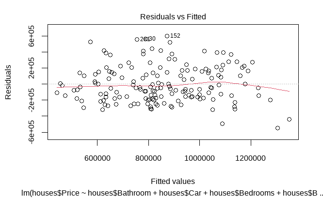

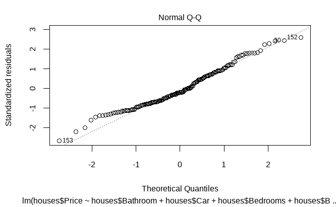

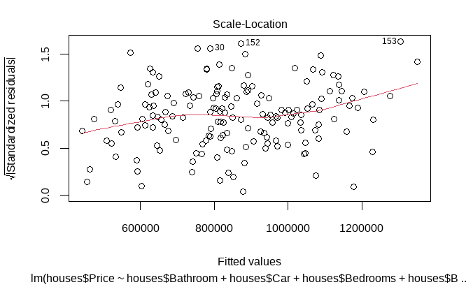

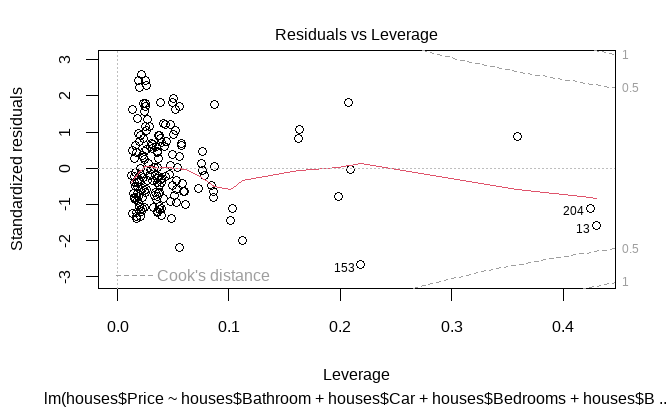

```r
plot(final_model.lm)
```

## 3.3 Suggest improvements to your model

What could be improved here is trying to preprocess the data again so we could compare the results when the missing values in the data would be removed or imputated using different methods. What also could be really beneficial is possibility to gather more data so then we would be able to remove the data without worrying too much about lack of data for building a prediction model.

# 4. Extension work

## 4.1 Model the likelihood of property being within 10 Miles of the commercial business district (using the urban.ind variable provided).

In order to model the likelihood of urban.ind being 1, I would start with inserting two categorical variables into the frequency table, and run chi-squared test

```r
table(houses$urban.ind, houses$Type)
```

```
      h   t   u
  0 115  11  23
  1  85  12  48
```

```r
chisq.test(table(houses$urban.ind, houses$Type))
```

```
    Pearson's Chi-squared test

data:  table(houses$urban.ind, houses$Type)
X-squared = 13.294, df = 2, p-value = 0.001298
```

Once again, I have started with a maximal model, and used na.omit() to omit the NA values

```r
houses2 <- na.omit(houses)

distance_model.glm <- glm(houses$urban.ind ~ houses$Rooms + houses$Type + houses$Price + houses$Bedrooms + houses$Bathroom + houses$Car + houses$Landsize + houses$BuildingArea + houses$YearBuilt + houses$Distance + houses$PropertyCount, family = "binomial")
distance_model2.glm <- glm(houses2$urban.ind ~ houses2$Rooms + houses2$Type + houses2$Price + houses2$Bedrooms + houses2$Bathroom + houses2$Car + houses2$Landsize + houses2$BuildingArea + houses2$YearBuilt + houses2$Distance + houses2$PropertyCount, family = "binomial")
summary(distance_model.glm)
```

```
Call:
glm(formula = houses$urban.ind ~ houses$Rooms + houses$Type +
    houses$Price + houses$Bedrooms + houses$Bathroom + houses$Car +
    houses$Landsize + houses$BuildingArea + houses$YearBuilt +
    houses$Distance + houses$PropertyCount, family = "binomial")

Deviance Residuals:
       Min          1Q      Median          3Q         Max
-6.712e-05  -2.100e-08  -2.100e-08   2.100e-08   6.867e-05

Coefficients:
                       Estimate Std. Error z value Pr(>|z|)
(Intercept)          -9.287e+02  1.546e+06  -0.001    1.000
houses$Rooms          2.595e+00  3.561e+05   0.000    1.000
houses$Typet         -5.681e+01  4.989e+04  -0.001    0.999
houses$Typeu         -1.159e+01  3.892e+04   0.000    1.000
houses$Price         -3.202e-05  4.287e-02  -0.001    0.999
houses$Bedrooms      -5.968e+00  3.564e+05   0.000    1.000
houses$Bathroom       2.853e+00  4.498e+04   0.000    1.000
houses$Car           -3.082e+00  8.489e+03   0.000    1.000
houses$Landsize      -2.032e-02  1.951e+01  -0.001    0.999
houses$BuildingArea   6.181e-02  5.278e+02   0.000    1.000
houses$YearBuilt      6.690e-01  8.410e+02   0.001    0.999
houses$Distance      -3.288e+01  8.382e+03  -0.004    0.997
houses$PropertyCount -2.050e-03  2.062e+00  -0.001    0.999

(Dispersion parameter for binomial family taken to be 1)

    Null deviance: 2.2713e+02  on 163  degrees of freedom
Residual deviance: 2.9825e-08  on 151  degrees of freedom
  (130 observations deleted due to missingness)
AIC: 26

Number of Fisher Scoring iterations: 25
```

Using stepwise selection now.

```r
step(distance_model.glm)
```

```
Start:  AIC=26
houses$urban.ind ~ houses$Rooms + houses$Type + houses$Price +
    houses$Bedrooms + houses$Bathroom + houses$Car + houses$Landsize +
    houses$BuildingArea + houses$YearBuilt + houses$Distance +
    houses$PropertyCount
```

```
                       Df Deviance    AIC
- houses$Type           2     0.00  22.00
- houses$Bedrooms       1     0.00  24.00
- houses$Rooms          1     0.00  24.00
- houses$BuildingArea   1     0.00  24.00
- houses$Bathroom       1     0.00  24.00
- houses$Landsize       1     0.00  24.00
- houses$Car            1     0.00  24.00
- houses$YearBuilt      1     0.00  24.00
- houses$Price          1     0.00  24.00
- houses$PropertyCount  1     0.00  24.00
<none>                        0.00  26.00
- houses$Distance       1   182.48 206.48
```

```
Step:  AIC=22
houses$urban.ind ~ houses$Rooms + houses$Price + houses$Bedrooms +
    houses$Bathroom + houses$Car + houses$Landsize + houses$BuildingArea +
    houses$YearBuilt + houses$Distance + houses$PropertyCount
```

```
                       Df Deviance    AIC
- houses$Bedrooms       1     0.00  20.00
- houses$Rooms          1     0.00  20.00
- houses$Landsize       1     0.00  20.00
- houses$YearBuilt      1     0.00  20.00
- houses$PropertyCount  1     0.00  20.00
- houses$Car            1     0.00  20.00
- houses$Bathroom       1     0.00  20.00
- houses$Price          1     0.00  20.00
- houses$BuildingArea   1     0.00  20.00
<none>                        0.00  22.00
- houses$Distance       1   189.17 209.17
```

```
Step:  AIC=20
houses$urban.ind ~ houses$Rooms + houses$Price + houses$Bathroom +
    houses$Car + houses$Landsize + houses$BuildingArea + houses$YearBuilt +
    houses$Distance + houses$PropertyCount
```

```
                       Df Deviance    AIC
- houses$Rooms          1     0.00  18.00
- houses$Landsize       1     0.00  18.00
- houses$YearBuilt      1     0.00  18.00
- houses$PropertyCount  1     0.00  18.00
- houses$Car            1     0.00  18.00
- houses$Price          1     0.00  18.00
- houses$Bathroom       1     0.00  18.00
- houses$BuildingArea   1     0.00  18.00
<none>                        0.00  20.00
- houses$Distance       1   189.25 207.25
```

```
Step:  AIC=18
houses$urban.ind ~ houses$Price + houses$Bathroom + houses$Car +
    houses$Landsize + houses$BuildingArea + houses$YearBuilt +
    houses$Distance + houses$PropertyCount
```

```
                       Df Deviance    AIC
- houses$YearBuilt      1     0.00  16.00
- houses$Landsize       1     0.00  16.00
- houses$PropertyCount  1     0.00  16.00
- houses$Car            1     0.00  16.00
- houses$Bathroom       1     0.00  16.00
- houses$BuildingArea   1     0.00  16.00
- houses$Price          1     0.00  16.00
<none>                        0.00  18.00
- houses$Distance       1   202.41 218.41
```

```r
final_distance_model.glm <- glm(formula = houses2$urban.ind ~ houses2$Distance, family = "binomial")
summary(final_distance_model.glm)
```

```
Call:
glm(formula = houses2$urban.ind ~ houses2$Distance, family = "binomial")

Deviance Residuals:
       Min          1Q      Median          3Q         Max
-3.676e-04  -2.000e-08  -2.000e-08   2.000e-08   1.984e-04

Coefficients:
                 Estimate Std. Error z value Pr(>|z|)
(Intercept)        1148.1   114606.6    0.01    0.992
houses2$Distance   -114.2    11390.9   -0.01    0.992

(Dispersion parameter for binomial family taken to be 1)

    Null deviance: 2.2713e+02  on 163  degrees of freedom
Residual deviance: 2.5317e-07  on 162  degrees of freedom
AIC: 4

Number of Fisher Scoring iterations: 25
```

$$log(\frac{p}{1-p})= 1148.1 - 114.2
\times Distance \times 1$$

```r
exp(coef(final_distance_model.glm))
```

```
     (Intercept) houses2$Distance
             Inf     2.582316e-50
```

# References

*De Jonge, Edwin, and Mark Van Der Loo. 2013. An Introduction to Data Cleaning with r. https://cran.r-project.org/doc/contrib/de_Jonge+van_der_Loo-Introduction_to_data_cleaning_with_R.pdf; Statistics Netherlands Heerlen.[Accessed: 7 August 2022]*

*Shepperd, M., Modern Data Book (2021). https://bookdown.org/martin_shepperd/ModernDataBook/ [Accessed: 8 August 2022]*

*Grolemund, Garrett, and Hadley Wickham. 2018. “R for Data Science.”*